# Lab 4 Team Collaboration

Andrew Maloney & Elaine Ob

3/28/2019

## Loading Data

```r
library(readxl)
library(dplyr)
```

```r
library(forcats)
library(ggplot2)
library(tidyr)
library(stringr)
library(reshape2)
defense <- read_excel('cyclonesFootball2018.xlsx', sheet = 'Defensive')

offense  <- read_excel('cyclonesFootball2018.xlsx', sheet = 'Offensive')

bio <- read_excel('cyclonesFootball2018.xlsx', sheet = 'Biography')
```

## Part One: Cleaning data

#### 1. The player names and opponent names are factors.

#### 2. All offensive and defensive statistics are numerical. The Weight column in biogrpahy is also numeric.

#### 3. Bonus: Change the Height column in biogrpahy into numeric.

```r
#str(defense)

defClean <- defense %>% mutate(Name = factor(Name), Opponent_Opponent = factor(Opponent_Opponent)) %>% mutate_at(vars(starts_with("Tack")), list(as.numeric)) %>% mutate_at(vars(starts_with("Turn")), list(as.numeric)) %>% mutate_at(vars(starts_with("Pass")), list(as.numeric))

str(defClean)
```

```
## Classes 'tbl_df', 'tbl' and 'data.frame':    446 obs. of  11 variables:
##  $ Name             : Factor w/ 42 levels "Akers, Landen",..: 7 7 7 7 7 7 7 7 7 7 ...
##  $ Opponent_Opponent: Factor w/ 13 levels "Akron","Baylor",..: 4 7 1 9 8 13 11 5 2 10 ...
##  $ Tackles_Solo     : num  3 6 7 6 3 5 3 7 2 9 ...
##  $ Tackles_ASST     : num  3 8 2 3 0 3 2 1 4 3 ...
##  $ Tackles_TFL      : num  0 1 1 0 1 1 0 0 0 0 ...
##  $ Tackles_Sack     : num  0 0 0 0 0 1 0 0 0 0 ...
##  $ Turnover_FF      : num  0 1 0 0 0 0 0 0 0 1 ...
##  $ Turnover_FR      : num  0 0 0 0 0 0 0 0 0 0 ...
##  $ Turnover_INT     : num  0 0 0 0 0 0 1 0 0 0 ...
##  $ Pass_QBH         : num  0 0 0 0 0 0 0 0 0 0 ...
##  $ Pass_PB          : num  0 0 3 0 0 0 0 0 0 0 ...
```

```r
print(defClean)
```

```
## # A tibble: 446 x 11
##    Name  Opponent_Oppone… Tackles_Solo Tackles_ASST Tackles_TFL
##    <fct> <fct>                   <dbl>        <dbl>       <dbl>
##  1 Eisw… Iowa                        3            3           0
##  2 Eisw… Oklahoma                    6            8           1
##  3 Eisw… Akron                       7            2           1
##  4 Eisw… TCU                         6            3           0
##  5 Eisw… Oklahoma State              3            0           1
##  6 Eisw… West Virginia               5            3           1
##  7 Eisw… Texas Tech                  3            2           0
##  8 Eisw… Kansas                      7            1           0
##  9 Eisw… Baylor                      2            4           0
## 10 Eisw… Texas                       9            3           0
## # … with 436 more rows, and 6 more variables: Tackles_Sack <dbl>,
## #   Turnover_FF <dbl>, Turnover_FR <dbl>, Turnover_INT <dbl>,
## #   Pass_QBH <dbl>, Pass_PB <dbl>
```

```r
#str(offense)

offClean <- offense %>% mutate(Name = factor(Name), Opponent_Opponent = factor(Opponent_Opponent)) %>% mutate_at(vars(starts_with("Rec")), list(as.numeric)) %>% mutate_at(vars(starts_with("Rush")), list(as.numeric)) %>% mutate_at(vars(starts_with("Pass")), list(as.numeric))
str(offClean)
```

```
## Classes 'tbl_df', 'tbl' and 'data.frame':    168 obs. of  12 variables:
##  $ Name             : Factor w/ 15 levels "Akers, Landen",..: 6 6 6 6 6 6 6 6 6 6 ...
##  $ Opponent_Opponent: Factor w/ 13 levels "Akron","Baylor",..: 4 7 1 9 8 13 11 5 2 10 ...
##  $ Receiving_REC    : num  1 9 6 3 6 1 1 4 4 0 ...
##  $ Receiving_YDS    : num  31 66 39 23 37 32 4 31 39 0 ...
##  $ Receiving_TD     : num  0 0 0 0 1 1 0 0 1 0 ...
##  $ Rushing_ATT      : num  NA NA NA NA NA NA NA NA NA NA ...
##  $ Rushing_YDS      : num  NA NA NA NA NA NA NA NA NA NA ...
##  $ Rushing_TD       : num  NA NA NA NA NA NA NA NA NA NA ...
##  $ Passing_CMP-ATT  : num  NA NA NA NA NA NA NA NA NA NA ...
##  $ Passing_YDS      : num  NA NA NA NA NA NA NA NA NA NA ...
##  $ Passing_TD       : num  NA NA NA NA NA NA NA NA NA NA ...
##  $ Passing_INT      : num  NA NA NA NA NA NA NA NA NA NA ...
```

```r
print(offClean)
```

```
## # A tibble: 168 x 12
##    Name  Opponent_Oppone… Receiving_REC Receiving_YDS Receiving_TD
##    <fct> <fct>                    <dbl>         <dbl>        <dbl>
##  1 Jone… Iowa                         1            31            0
##  2 Jone… Oklahoma                     9            66            0
##  3 Jone… Akron                        6            39            0
##  4 Jone… TCU                          3            23            0
##  5 Jone… Oklahoma State               6            37            1
##  6 Jone… West Virginia                1            32            1
##  7 Jone… Texas Tech                   1             4            0
##  8 Jone… Kansas                       4            31            0
##  9 Jone… Baylor                       4            39            1
## 10 Jone… Texas                        0             0            0
## # … with 158 more rows, and 7 more variables: Rushing_ATT <dbl>,
## #   Rushing_YDS <dbl>, Rushing_TD <dbl>, `Passing_CMP-ATT` <dbl>,
## #   Passing_YDS <dbl>, Passing_TD <dbl>, Passing_INT <dbl>
```

```r
bioClean <- bio %>% mutate(Weight = as.numeric(Weight)) %>% separate(Height, c("Feet", "Inches"), "-", convert = TRUE) %>% mutate(Height_in_Centimeters = ((Feet*12) + Inches)*2.54)

str(bioClean)
```

```
## Classes 'tbl_df', 'tbl' and 'data.frame':    123 obs. of  9 variables:
##  $ Name                 : chr  "Akers, Landen" "Allen, Chase" "Alt, Gerry" "Anderson, Cole" ...
##  $ Position             : chr  "Wide Receiver" "Tight End" "Offensive Line" "Tight End" ...
##  $ Feet                 : int  6 6 6 6 6 5 6 6 6 6 ...
##  $ Inches               : int  0 7 2 4 0 11 0 3 2 2 ...
##  $ Weight               : num  192 240 290 250 191 205 192 224 251 284 ...
##  $ Class                : chr  "Redshirt Sophomore" "Redshirt Sophomore" "Redshirt Freshman" "Redshirt Senior" ...
##  $ Hometown             : chr  "Cedar Rapids, Iowa" "Nixa, Mo." "Cedar Rapids, Iowa" "League City, Texas" ...
##  $ Highschool           : chr  "Washington" "Nixa" "Washington" "Clear Falls" ...
##  $ Height_in_Centimeters: num  183 201 188 193 183 ...
```

```r
print(bioClean)
```

```
## # A tibble: 123 x 9
##    Name  Position  Feet Inches Weight Class Hometown Highschool
##    <chr> <chr>    <int>  <int>  <dbl> <chr> <chr>    <chr>
##  1 Aker… Wide Re…     6      0    192 Reds… Cedar R… Washington
##  2 Alle… Tight E…     6      7    240 Reds… Nixa, M… Nixa
##  3 Alt,… Offensi…     6      2    290 Reds… Cedar R… Washington
##  4 Ande… Tight E…     6      4    250 Reds… League … Clear Fal…
##  5 Assa… Placeki…     6      0    191 Reds… Napervi… Central
##  6 Aust… Linebac…     5     11    205 Reds… Walnut,… Bishop Am…
##  7 Azun… Defensi…     6      0    192 Reds… Grand P… Lake Ridge
##  8 Bail… Defensi…     6      3    224 Reds… Clarksd… Clarksdale
##  9 Bail… Defensi…     6      2    251 Juni… Jackson… Raines
## 10 Bail… Defensi…     6      2    284 Reds… Jackson… Raines
## # … with 113 more rows, and 1 more variable: Height_in_Centimeters <dbl>
```

## Part Two: Tidying(1)

#### 1. Reformat the defClean data frame into a tidy format using gather. The type of statistic (Tackles_Solo, Tackles_ASST, etc) is added as a new key column named Statistic.

```r
defClean_Tidy <- defClean %>% gather(key = Statistic, value = Count, 3:11)
print(defClean_Tidy)
```

```
## # A tibble: 4,014 x 4
##    Name           Opponent_Opponent Statistic    Count
##    <fct>          <fct>             <chr>        <dbl>
##  1 Eisworth, Greg Iowa              Tackles_Solo     3
##  2 Eisworth, Greg Oklahoma          Tackles_Solo     6
##  3 Eisworth, Greg Akron             Tackles_Solo     7
##  4 Eisworth, Greg TCU               Tackles_Solo     6
##  5 Eisworth, Greg Oklahoma State    Tackles_Solo     3
##  6 Eisworth, Greg West Virginia     Tackles_Solo     5
##  7 Eisworth, Greg Texas Tech        Tackles_Solo     3
##  8 Eisworth, Greg Kansas            Tackles_Solo     7
##  9 Eisworth, Greg Baylor            Tackles_Solo     2
## 10 Eisworth, Greg Texas             Tackles_Solo     9
## # … with 4,004 more rows
```

#### 2. Create a histogram for each defensive statistic. Use facet_wrap to draw all histograms in a single plot. What defensive skills are rare?

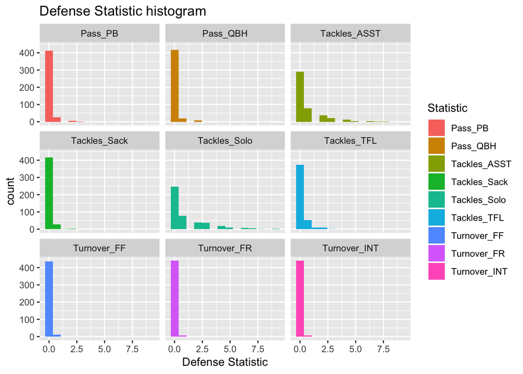

```r
defClean_Tidy %>% ggplot(aes(x = Count, fill = Statistic))+
  geom_histogram(binwidth = 0.7) + facet_wrap(~Statistic)+
  ggtitle("Defense Statistic histogram") + xlab("Defense Statistic")
```

Looking at the 9 histograms we can see that the Turnovers are a rare defensive skill. This makes sense to anyone who has watched a football game. Turnover plays do not happen often.

#### 3. Did ISU have better defense against West Virginia or Kansas State?

```r
Teams <- c("West Virginia", "Kansas State")
defClean_Tidy_Teams <- defClean_Tidy %>% filter(Opponent_Opponent %in% Teams) %>% spread(key = Opponent_Opponent, value = Count) %>% filter(Statistic == "Tackles_Solo")

print(defClean_Tidy_Teams)
```

```
## # A tibble: 37 x 4
##    Name               Statistic    `Kansas State` `West Virginia`
##    <fct>              <chr>                 <dbl>           <dbl>
##  1 Akers, Landen      Tackles_Solo              1               0
##  2 Azunna, Arnold     Tackles_Solo              0              NA
##  3 Bailey, Cordarrius Tackles_Solo              0               0
##  4 Bailey, JaQuan     Tackles_Solo              0               2
##  5 Benton, Spencer    Tackles_Solo              0               1
##  6 Butler, Hakeem     Tackles_Solo              0               1
##  7 Eisworth, Greg     Tackles_Solo              3               5
##  8 Francis, Chris     Tackles_Solo              0               0
##  9 Grant, Jatairis    Tackles_Solo              1               0
## 10 Greene, Conner     Tackles_Solo              0              NA
## # … with 27 more rows
```

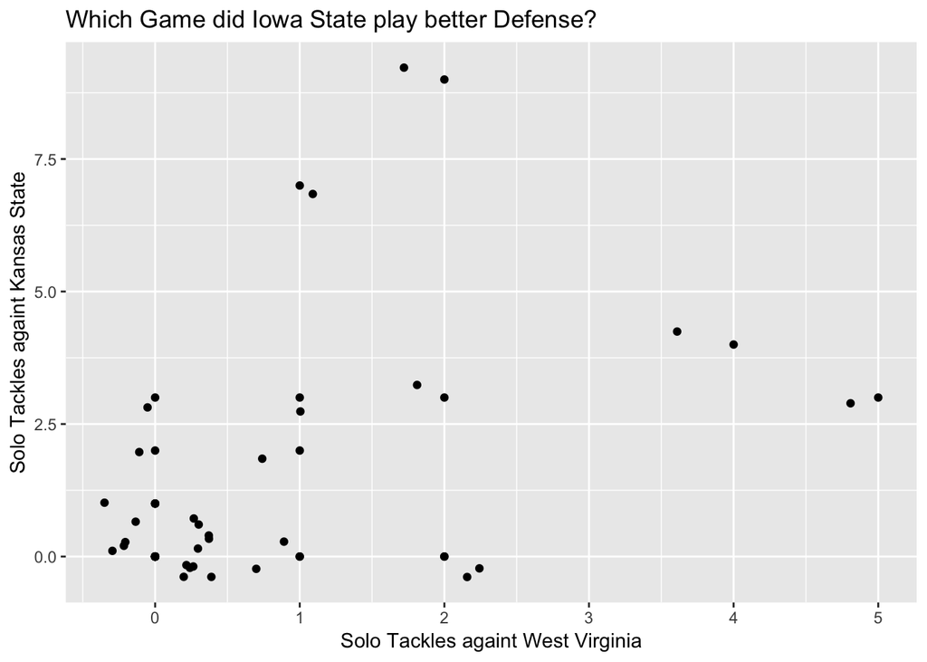

```r
defClean_Tidy_Teams %>% ggplot(aes(x = `West Virginia`, y = `Kansas State`))+
  geom_point(na.rm = TRUE) + geom_jitter(na.rm = TRUE)+
  ggtitle("Which Game did Iowa State play better Defense?") + xlab("Solo Tackles againt West Virginia") +ylab("Solo Tackles againt Kansas State")
```

```r
#defClean %>% select(Name, Opponent_Opponent, Tackles_Solo) %>% spread(Opponent_Opponent, Tackles_Solo) %>% ggplot(aes(x = `West Virginia`, y = `Kansas State`)) + geom_point()
```

Looking at the newly created data frame and scatterplot, we can see Iowa State had a significanlty better defense game against Kansas State then when playing West Virginia.

## Part Two: Tidying(2)

#### 1. Separate the Hometown column into two columns, namely the city and the state. Print the first few rows of these two columns.

#### 2. How many players are there from each state?

```r
#str(bioClean)

bioClean_Tidy <- bioClean %>% separate(Hometown, c("City", "State"), ",", convert = TRUE )
print(bioClean_Tidy, 3)
```

```
## # A tibble: 123 x 10
##    Name  Position  Feet Inches Weight Class City  State Highschool
##    <chr> <chr>    <int>  <int>  <dbl> <chr> <chr> <chr> <chr>
##  1 Aker… Wide Re…     6      0    192 Reds… Ceda… " Io… Washington
##  2 Alle… Tight E…     6      7    240 Reds… Nixa  " Mo… Nixa
##  3 Alt,… Offensi…     6      2    290 Reds… Ceda… " Io… Washington
##  4 Ande… Tight E…     6      4    250 Reds… Leag… " Te… Clear Fal…
##  5 Assa… Placeki…     6      0    191 Reds… Nape… " Il… Central
##  6 Aust… Linebac…     5     11    205 Reds… Waln… " Ca… Bishop Am…
##  7 Azun… Defensi…     6      0    192 Reds… Gran… " Te… Lake Ridge
##  8 Bail… Defensi…     6      3    224 Reds… Clar… " Mi… Clarksdale
##  9 Bail… Defensi…     6      2    251 Juni… Jack… " Fl… Raines
## 10 Bail… Defensi…     6      2    284 Reds… Jack… " Fl… Raines
## # … with 113 more rows, and 1 more variable: Height_in_Centimeters <dbl>
```

```r
Players_State <- table(bioClean_Tidy$State)
print(Players_State)
```

```
##
##      Ariz.       Ark.  Australia     Calif.       D.C.       Fla.
##          3          2          2          8          1          8
##        Ga.       Ill.       Iowa       Kan.      Mass.        Md.
##          2          5         44          3          1          1
##      Mich.      Minn.      Miss.        Mo.       Neb.    Nigeria
##          5          2          1          1          1          1
##       Ohio      Okla.        Pa.       S.C.      Texas        Va.
##         10          4          2          2          9          1
##       Wis.
##          4
```

## Part Three: Joing Dataframes

#### 1. Find where do the offensive players come from by joining the offensive data and player biography data appropriately.

```r
Joined_Offense_with_Biography <- inner_join(offClean, bioClean_Tidy, by = "Name")
Players_Origin <- Joined_Offense_with_Biography %>% distinct(Name, City, State, Highschool)
print(Joined_Offense_with_Biography)
```

```
## # A tibble: 163 x 21
##    Name  Opponent_Oppone… Receiving_REC Receiving_YDS Receiving_TD
##    <chr> <fct>                    <dbl>         <dbl>        <dbl>
##  1 Jone… Iowa                         1            31            0
##  2 Jone… Oklahoma                     9            66            0
##  3 Jone… Akron                        6            39            0
##  4 Jone… TCU                          3            23            0
##  5 Jone… Oklahoma State               6            37            1
##  6 Jone… West Virginia                1            32            1
##  7 Jone… Texas Tech                   1             4            0
##  8 Jone… Kansas                       4            31            0
##  9 Jone… Baylor                       4            39            1
## 10 Jone… Texas                        0             0            0
## # … with 153 more rows, and 16 more variables: Rushing_ATT <dbl>,
## #   Rushing_YDS <dbl>, Rushing_TD <dbl>, `Passing_CMP-ATT` <dbl>,
## #   Passing_YDS <dbl>, Passing_TD <dbl>, Passing_INT <dbl>,
## #   Position <chr>, Feet <int>, Inches <int>, Weight <dbl>, Class <chr>,
## #   City <chr>, State <chr>, Highschool <chr>, Height_in_Centimeters <dbl>
```

```r
print(Players_Origin)
```

```
## # A tibble: 14 x 4
##    Name              City         State    Highschool
##    <chr>             <chr>        <chr>    <chr>
##  1 Jones, Deshaunte  Cincinnati   " Ohio"  Colerain
##  2 Milton, Tarique   Bradenton    " Fla."  Manatee
##  3 Butler, Hakeem    Baltimore    " Md."   Travis {Texas}
##  4 Lang, Johnnie     Palmetto     " Fla."  Salt Lake City East {Utah}
##  5 Akers, Landen     Cedar Rapids " Iowa"  Washington
##  6 Kolar, Charlie    Norman       " Okla." North
##  7 Montgomery, David Cincinnati   " Ohio"  Mount Healthy
##  8 Purdy, Brock      Gilbert      " Ariz." Perry
##  9 Nwangwu, Kene     Frisco       " Texas" Heritage
## 10 Kempt, Kyle       Massillon    " Ohio"  Washington
## 11 Eaton, Matthew    Norfolk      " Va."   Pascagoula {Miss.}
## 12 Allen, Chase      Nixa         " Mo."   Nixa
## 13 Seonbuchner, Sam  Oconomowoc   " Wis."  Arrowhead
## 14 Johnson, Josh     Little Rock  " Ark."  Central Arkansas Christian
```

#### 2. Is there a relationship between the weight of a player and the receiving yards (Receiving_YDS)?

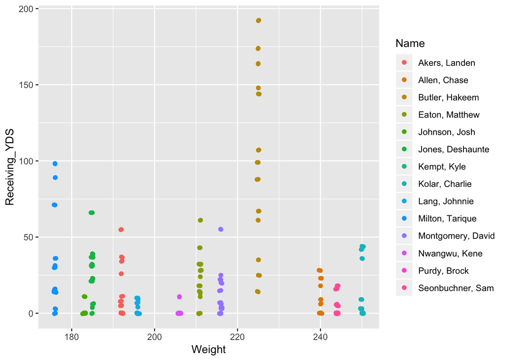

```r
Joined_Offense_with_Biography %>% ggplot(aes(x = Weight, y = Receiving_YDS, color = Name))+
  geom_point(na.rm = TRUE) + geom_jitter(na.rm = TRUE)
```

There does not seem to be a relationship between the weight of a player and the amount of receiving yards. It is more likely that there is a relationship between the position the player plays and the amount of receiving yards.

#### 3. Explore more. Raise a question that can be answered only by looking at two or more data frames. Then answer that question.

New Question: Is there anything we can conclude from the Height and Weight of a player to the positions of a player on Iowa State Football Team?

```r
Joined_Defense_with_Biography <- inner_join(defClean, bioClean_Tidy, by = "Name")
Complete_Join_Biography <- full_join(Joined_Defense_with_Biography, Joined_Offense_with_Biography)
Complete_Join_Biography_2 <- Complete_Join_Biography %>% distinct(Name, Position, Weight, Height_in_Centimeters)
print(Complete_Join_Biography_2)
```

```
## # A tibble: 50 x 4
##    Name            Position       Weight Height_in_Centimeters
##    <chr>           <chr>           <dbl>                 <dbl>
##  1 Eisworth, Greg  Defensive Back    198                  183.
##  2 Harvey, Willie  Linebacker        224                  183.
##  3 Rose, Mike      Linebacker        228                  190.
##  4 Lewis, Braxton  Defensive Back    186                  180.
##  5 Peavy, Brian    Defensive Back    194                  175.
##  6 White, Lawrence Defensive Back    191                  183.
##  7 Bailey, JaQuan  Defensive End     251                  188.
##  8 Payne, D'Andre  Defensive Back    188                  178.
##  9 Lima, Ray       Defensive Line    302                  190.
## 10 Hummel, Jake    Linebacker        228                  185.
## # … with 40 more rows
```

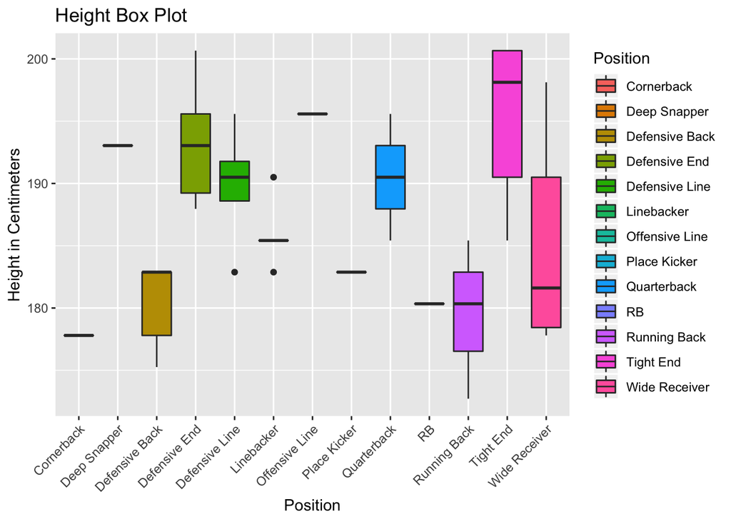

```r
Complete_Join_Biography_2 %>% ggplot(aes(x = Position, y = Height_in_Centimeters, fill = Position))+
  geom_boxplot(na.rm = TRUE)+
  ggtitle("Height Box Plot") + xlab("Position") +ylab("Height in Centimeters") + theme(axis.text.x = element_text(angle = 45, vjust = 1, hjust = 1))
```

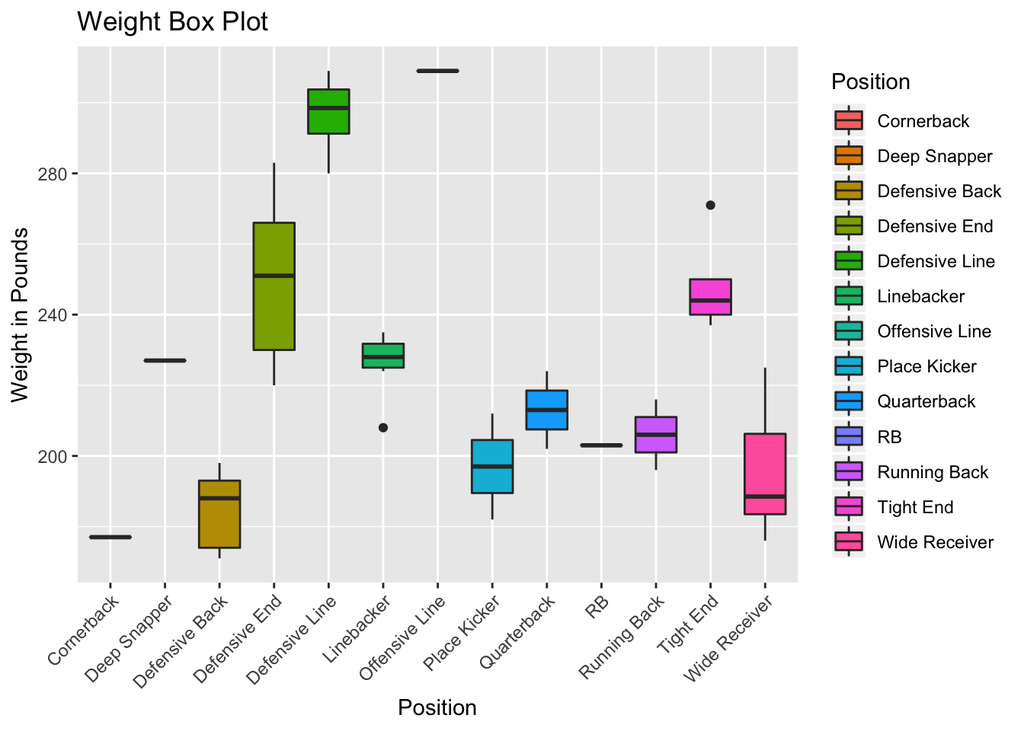

```r
Complete_Join_Biography_2 %>% ggplot(aes(x = Position, y = Weight, fill = Position))+
  geom_boxplot(na.rm = TRUE)+
  ggtitle("Weight Box Plot") + xlab("Position") +ylab("Weight in Pounds") + theme(axis.text.x = element_text(angle = 45, vjust = 1, hjust = 1))
```

Cornerbacks tend to be smaller players with a smaller stature and lower weight. Deep snappers seems to be taller and normal weight. Defensive backs tend to be smaller players with a lower weight and height. Defensive ends have a higher weight and taller than normal. Defensive line players have a normal height with a higher weight. Line backers seem to have a height around 6’0-6’2" and a weight of 210 to 235 pounds.